# Group B11 Vendex Challenge-1

General Overview and Data treatment

# Libraries

Importing all the necessary libraries

```r
library(data.table)
library(readxl)
library(tidyverse)
library(janitor)
library(lubridate)
library(tidymodels)
library(GGally)
library(corrplot)
```

# Loading Data

```r
files <- list.files(path = '~/Desktop/R_Course/Assignments',
                    pattern = '.csv', full.names = TRUE)

machines <- read.csv(files[1])
products <- read.csv(files[2])
txns <- read.csv(files[3])
```

# Challenge Solution

## Question-1

**Machines** :

### a

There are **2495** machines.

```r
n.machines = length(unique(machines$machine))
n.machines
```

```
[1] 2495
```

### b

**38.4%** of the machines are small.

```r
per.small_machines = round(mean(machines$small_machine==1)*100,1)
per.small_machines
```

```
[1] 38.4
```

### c

**58%** of the machines are located in the *transport* location whereas **14%** & **28%** of them are located in *petrol station* & *other* locations respectively.

```r
dis.location = prop.table(table(machines$location_type))
dis.location = round(dis.location*100, 1)
dis.location
```

```
        others petrol station      transport
          27.7           13.8           58.5
```

**Products** :

### d

There are **63** products. *Carbonates and energy drinks* category has the highest number of products with **13** different products.

```r
n.products = length(unique(products$product_name))
n.products
```

```
[1] 63
```

```r
#Number of drinks per category sorted in decreasing order
products %>%
  group_by(products$category) %>%
  summarise(count=n()) %>%
  arrange(desc(count))
```

```
# A tibble: 8 × 2
  `products$category`           count
  <chr>                         <int>
1 Carbonates and energy drinks     13
2 Chocolate based                  11
3 Juice, tea and smoothies          8
4 Salty                             8
5 Cookies, pastries and cereals     7
6 Sugar candy                       7
7 Water                             5
8 Milk based                        4
```

### e

**Milk based** category has the highest average price of **3.42** and falls under the *drink* category. **Sugar candy** category has the lowest average price of **2.3** and falls under the *snack* category.

```r
#Average price grouped by category & type
price_cat_type <- products %>%
                  group_by(category, type_drink_snack) %>%
                  summarise(avg_price=mean(price, na.rm = TRUE)) %>%
                  arrange(desc(avg_price))
price_cat_type
```

```
# A tibble: 8 × 3
# Groups:   category [8]
  category                      type_drink_snack avg_price
  <chr>                         <chr>                <dbl>
1 Milk based                    drink                 3.42
2 Carbonates and energy drinks  drink                 3.26
3 Water                         drink                 3.26
4 Juice, tea and smoothies      drink                 2.86
5 Salty                         snack                 2.72
6 Cookies, pastries and cereals snack                 2.39
7 Chocolate based               snack                 2.31
8 Sugar candy                   snack                 2.3
```

**Transactional data** :

### f

In March 2017, the average daily sales of *small* & *big* machines are **7058** & **14666** respectively.

```r
#Adding a new column in the txns datarame called month
txns$month = month(as.Date(txns$timestamp))

#Calculating number of unique days
unique_days_in_march = length(unique((txns %>% filter(month==3))$date))

#Calculating the avg daily sales for small & big machines in March
txns %>%
    filter(month==3) %>%
    group_by(machine) %>%
    summarise(total_sales_in_march = n()) %>%
    left_join(machines, by='machine') %>%
    select(machine, total_sales_in_march, small_machine) %>%
    aggregate(total_sales_in_march ~ small_machine, FUN = sum) %>%
    mutate(avg_daily_sales_in_march =  round(total_sales_in_march/unique_days_in_march)) %>%
    select(small_machine, avg_daily_sales_in_march)
```

```
  small_machine avg_daily_sales_in_march
1             0                    14666
2             1                     7058
```

**Potential reasons for this difference** :

- The small machines by definition have lesser storage capacity and once they are out of stock, it usually takes a day or two to replenish them.
- It is possible that big machines have more variety of products and hence higher sales.
- It is also possible that the small machines hold products from a category that has lower average prices.

## Question-2

### a

**Yes**, there seems to be a general trend in the number of sales of both snacks & drinks. This trend is **same** for both snacks & drinks. The general trend for **both** snacks & drinks is as follows :

In a given month, **there seem to be 4 peak (same peak days for both snacks & drinks) days** where the sales of both snacks & drinks shoot up. It so happens that these peak days are **Mondays**. On Monday, people get back to work and are usually less motived to work. They probably require some snacks or drinks to keep them going and hence this peak in sales every Monday.

### b

**Yes**, there also seems to be a shorter time period trend. This is **not same** for snacks & drinks. As we go from January (winter) to April (Spring) the temperature increases and hence the sales of drinks shoot up. For snacks though, the trend is generally stable with a slight dip when the months are March & April.

## Question-3

### a

The `income_average` column in machines data **does contain outliers**. This can be seen by plotting the histogram for this particular column.

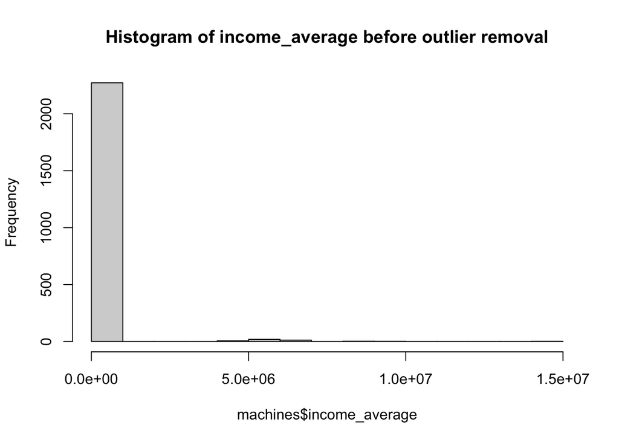

```r
hist(machines$income_average,
     main='Histogram of income_average before outlier removal')
```

**These outliers need to be removed**, as the abnormal high value of the `income_average` for these instances will cause **bias** in the linear model that will be created later in this exercise. In this case, it is a good idea to remove outliers that are **above & below 1.5 times the inter-quartile range**. The following code block depicts the necessary steps

```r
#Calculating the interquartile range
quantiles = quantile(machines$income_average, na.rm=TRUE)
iqr = quantiles[4]-quantiles[2]


machines <- machines %>%
          filter(is.na(income_average)|income_average <= quantiles[4]+(1.5*iqr)) %>%
          filter(is.na(income_average)|income_average >= quantiles[2]-(1.5*iqr))
```

After removing the outliers, the `machines` dataframe contains **2311** observations (*184 outliers were removed*) Now that the outliers have been removed, lets plot the histogram again for the same data.

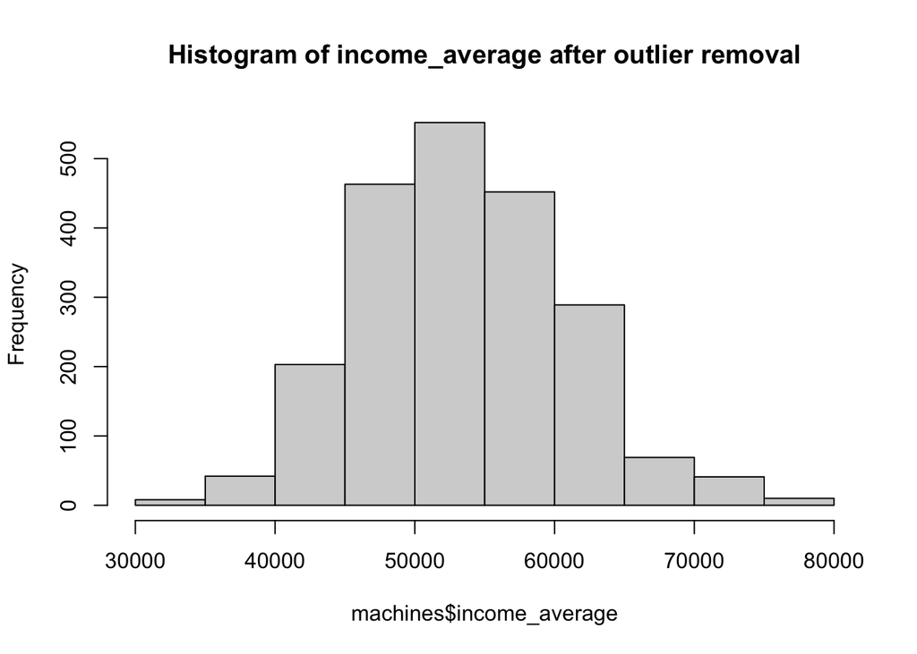

```r
hist(machines$income_average,
     main='Histogram of income_average after outlier removal')
```

### b

There are 4 ways of treating missing values of the `income_average` column. They are mentioned below :

1. Dropping the rows which have `income_average` as NA.
2. Replace NAs by a particular value using the `replace_na()` function.
3. Fill NAs with the previous or next value using the `fill()` function.
4. Fill NAs using aggregate values like **mean** or **median**.

We go ahead with final option i.e. we replace the NAs by **mean** of the `income_average` column. This is because we know that there are 182 NAs in `income_average`(~8% of the data). We do not want to lose information about other features for these 182 instances as we believe that 8% is a sizable portion of data. The reason behind filling the NAs with **mean** instead of other constant value or the previous or next value is that we have arrived from the previous question that the distribution of the `income_average` column is almost normal and hence imputing the NAs with mean makes sense. Please find the code below :

```r
machines$income_average[is.na(machines$income_average)] <- mean(machines$income_average,
                                                                na.rm=TRUE)
```

Checking the distribution of `income_average` column.

```r
summary(machines$income_average)
```

```
   Min. 1st Qu.  Median    Mean 3rd Qu.    Max.
  31570   48637   53233   53233   56478   76928
```

**The NAs have been successfully removed!**

## Question-4

The median number of hotels in the machine area are **0**.

```r
median(machines$num_hotels, na.rm = TRUE)
```

```
[1] 0
```

This can also be seen from the below Box Plot and the one given in the question.

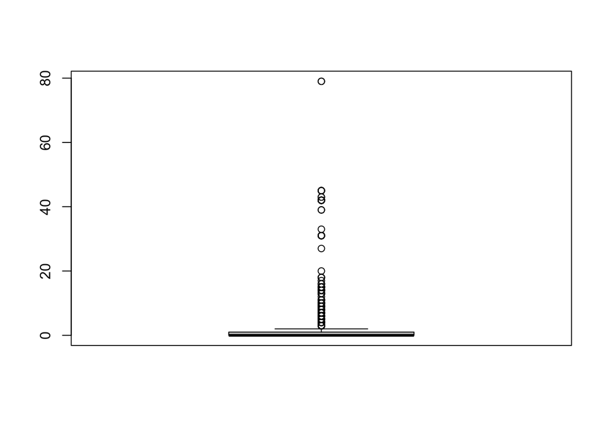

```r
boxplot(machines$num_hotels)
```

## Question-5

### a

Creating a new dataframe **`sales`** which contains 3 columns **`sales$machine`**, **`sales$total_sales`** & **`sales$avg_daily_sales`**. This dataframe will be later merged with **`machines`**.

```r
#Calculating number of unique days
unique_days = length(unique(txns$date))

#Creating the new dataframe sales to calculate average daily sales for each machine
sales <- txns %>%
            group_by(machine) %>%
            summarise(total_sales = n())

sales$avg_daily_sales <- round(sales$total_sales/unique_days)

head(sales)
```

```
# A tibble: 6 × 3
  machine total_sales avg_daily_sales
    <int>       <int>           <dbl>
1       1         765               8
2       2         644               7
3     179         486               5
4     180         236               3
5     181         497               6
6     182        1417              16
```

```r
df <- machines %>%
      left_join(sales, by='machine') %>%
      mutate(petrol_others = ifelse(is.na(train_AvgDailyPassengers),1,0)) %>%
      select(machine,
             avg_daily_sales,
             small_machine,
             income_average,
             total_number_of_routes_600,
             num_hotels_45,
             petrol_others,
             num_vendex_nearby_300)

#Displaying the head of df
head(df)
```

```
  machine avg_daily_sales small_machine income_average
1       1               8             0       53233.24
2       2               7             0       53233.24
3     179               5             1       51962.00
4     180               3             1       47359.00
5     181               6             0       61219.00
6     182              16             0       47051.00
  total_number_of_routes_600 num_hotels_45 petrol_others num_vendex_nearby_300
1                         65             0             1                     1
2                         65             0             1                     1
3                          6             0             1                     0
4                         11             0             1                     2
5                         10             0             1                     0
6                        127             2             0                     5
```

Checking the summary of `df`

```r
summary(df)
```

```
    machine       avg_daily_sales  small_machine    income_average
 Min.   :   1.0   Min.   : 1.000   Min.   :0.0000   Min.   :31570
 1st Qu.: 793.5   1st Qu.: 4.000   1st Qu.:0.0000   1st Qu.:48637
 Median :1435.0   Median : 7.000   Median :0.0000   Median :53233
 Mean   :1435.3   Mean   : 8.029   Mean   :0.3864   Mean   :53233
 3rd Qu.:2069.5   3rd Qu.:10.000   3rd Qu.:1.0000   3rd Qu.:56478
 Max.   :2724.0   Max.   :50.000   Max.   :1.0000   Max.   :76928

 total_number_of_routes_600 num_hotels_45     petrol_others
 Min.   :  1.0              Min.   : 0.0000   Min.   :0.0000
 1st Qu.:  7.0              1st Qu.: 0.0000   1st Qu.:0.0000
 Median : 15.0              Median : 0.0000   Median :1.0000
 Mean   : 47.1              Mean   : 0.6586   Mean   :0.5175
 3rd Qu.: 36.0              3rd Qu.: 0.0000   3rd Qu.:1.0000
 Max.   :866.0              Max.   :36.0000   Max.   :1.0000
 NA's   :100
 num_vendex_nearby_300
 Min.   : 0.000
 1st Qu.: 0.000
 Median : 1.000
 Mean   : 2.091
 3rd Qu.: 2.000
 Max.   :64.000
```

It seems that the `df$total_number_of_routes_600` column still has some NAs. These missing values are replaced by the mean of the column.

```r
#Replacing the missing values in the route column and rounding
df$total_number_of_routes_600[is.na(df$total_number_of_routes_600)] <- mean(df$total_number_of_routes_600, na.rm = TRUE)
df$total_number_of_routes_600 = round(df$total_number_of_routes_600)
```

Creating the linear model to predict the `avg_daily_sales`

```r
# We select the relevant variables for modelling
df_lm_model <- lm(formula = avg_daily_sales ~
                    small_machine +
                    income_average +
                    total_number_of_routes_600 +
                    num_hotels_45 +
                    petrol_others +
                    num_vendex_nearby_300 , data = df)

#Checking the summary of the linear model
summary(df_lm_model)
```

```
Call:
lm(formula = avg_daily_sales ~ small_machine + income_average +
    total_number_of_routes_600 + num_hotels_45 + petrol_others +
    num_vendex_nearby_300, data = df)

Residuals:
    Min      1Q  Median      3Q     Max
-12.090  -2.952  -0.991   1.914  43.379

Coefficients:
                             Estimate Std. Error t value Pr(>|t|)
(Intercept)                 1.124e+01  7.853e-01  14.307  < 2e-16 ***
small_machine              -1.723e+00  2.015e-01  -8.548  < 2e-16 ***
income_average             -1.807e-05  1.429e-05  -1.265    0.206
total_number_of_routes_600  1.225e-03  1.853e-03   0.661    0.509
num_hotels_45               4.022e-01  5.752e-02   6.993 3.52e-12 ***
petrol_others              -3.497e+00  2.053e-01 -17.038  < 2e-16 ***
num_vendex_nearby_300      -4.424e-02  3.466e-02  -1.277    0.202
---
Signif. codes:  0 '***' 0.001 '**' 0.01 '*' 0.05 '.' 0.1 ' ' 1

Residual standard error: 4.713 on 2304 degrees of freedom
Multiple R-squared:  0.181, Adjusted R-squared:  0.1789
F-statistic: 84.86 on 6 and 2304 DF,  p-value: < 2.2e-16
```

`income_average`, `total_number_of_routes_600` & `num_vendex_nearby_300` **do not** show statistical significance. This is because their p-value is greater than 0.05

By default, R considers 95% confidence intervals and a p-value above 0.05 for a variable means that the probability of the coefficient of that variable being 0 is high. Hence we deduce that the coefficients for all the variables with p-value greater than 0.05 to be 0.

### b

Creating a new column called `df$log_transport`

```r
df$log_transport <-log (df$total_number_of_routes_600, base=10)
```

Building a new model by replacing `df\$total_number_of_routes_600` with `df$log_transport`

```r
df_lm_model_2 <- lm(formula = avg_daily_sales ~
                      small_machine +
                      income_average +
                      log_transport +
                      num_hotels_45 +
                      petrol_others +
                      num_vendex_nearby_300 , data = df)

#Lets summarize the attributes of the model
summary(df_lm_model_2)
```

```
Call:
lm(formula = avg_daily_sales ~ small_machine + income_average +
    log_transport + num_hotels_45 + petrol_others + num_vendex_nearby_300,
    data = df)

Residuals:
    Min      1Q  Median      3Q     Max
-11.410  -2.972  -0.883   1.921  42.693

Coefficients:
                        Estimate Std. Error t value Pr(>|t|)
(Intercept)            9.069e+00  8.178e-01  11.089  < 2e-16 ***
small_machine         -1.675e+00  1.987e-01  -8.429  < 2e-16 ***
income_average        -1.696e-05  1.408e-05  -1.204    0.229
log_transport          1.780e+00  2.160e-01   8.242 2.80e-16 ***
num_hotels_45          3.160e-01  5.054e-02   6.253 4.80e-10 ***
petrol_others         -3.237e+00  2.046e-01 -15.825  < 2e-16 ***
num_vendex_nearby_300 -1.078e-01  2.460e-02  -4.382 1.23e-05 ***
---
Signif. codes:  0 '***' 0.001 '**' 0.01 '*' 0.05 '.' 0.1 ' ' 1

Residual standard error: 4.645 on 2304 degrees of freedom
Multiple R-squared:  0.2043,    Adjusted R-squared:  0.2022
F-statistic: 98.59 on 6 and 2304 DF,  p-value: < 2.2e-16
```

In this new model, the new variable `df$log_transport` is **significant** as it has a p-value less than 0.05

### c,d,e,f

Training a linear model by removing the variables that DO NOT show statistical significance (`df$income_average` is not considered because it’s coefficient was not statistically significant)

```r
final_model <- lm(formula = avg_daily_sales ~
                    small_machine +
                    log_transport +
                    num_hotels_45 +
                    petrol_others +
                    num_vendex_nearby_300 , data = df)

#Lets summarize the attributes of the final model
summary(final_model)
```

```
Call:
lm(formula = avg_daily_sales ~ small_machine + log_transport +
    num_hotels_45 + petrol_others + num_vendex_nearby_300, data = df)

Residuals:
    Min      1Q  Median      3Q     Max
-11.402  -2.967  -0.878   1.850  42.730

Coefficients:
                      Estimate Std. Error t value Pr(>|t|)
(Intercept)            8.15717    0.30946  26.359  < 2e-16 ***
small_machine         -1.66908    0.19868  -8.401  < 2e-16 ***
log_transport          1.78293    0.21599   8.255 2.53e-16 ***
num_hotels_45          0.30778    0.05008   6.146 9.36e-10 ***
petrol_others         -3.21975    0.20407 -15.778  < 2e-16 ***
num_vendex_nearby_300 -0.10806    0.02460  -4.392 1.17e-05 ***
---
Signif. codes:  0 '***' 0.001 '**' 0.01 '*' 0.05 '.' 0.1 ' ' 1

Residual standard error: 4.646 on 2305 degrees of freedom
Multiple R-squared:  0.2038,    Adjusted R-squared:  0.2021
F-statistic:   118 on 5 and 2305 DF,  p-value: < 2.2e-16
```

#### c

When all other factors remain the same, small machines on an average sell **1.7 less items daily** compared to big machines. This is calculated by just looking at the coefficient of `small_machine`.

```r
final_model$coefficients['small_machine']
```

```
small_machine
    -1.669085
```

#### d

When all other factors remain the same, having 1 more unit of a nearby machine will result in **an average drop in sales by 0.10** units. This is calculated by just looking at the coefficient of `num_vendex_nearby_300`.

```r
final_model$coefficients['num_vendex_nearby_300']
```

```
num_vendex_nearby_300
           -0.1080575
```

#### e

Creating a new column called `.pred` that **stores the model predictions** for each row.

```r
df <- df %>%
      bind_cols(predict(final_model, newdata = df)) %>%
      rename(.preds = ...10)
#Dsiplaying the head of df
head(df)
```

```
  machine avg_daily_sales small_machine income_average
1       1               8             0       53233.24
2       2               7             0       53233.24
3     179               5             1       51962.00
4     180               3             1       47359.00
5     181               6             0       61219.00
6     182              16             0       47051.00
  total_number_of_routes_600 num_hotels_45 petrol_others num_vendex_nearby_300
1                         65             0             1                     1
2                         65             0             1                     1
3                          6             0             1                     0
4                         11             0             1                     2
5                         10             0             1                     0
6                        127             2             0                     5
  log_transport    .preds
1     1.8129134  8.061662
2     1.8129134  8.061662
3     0.7781513  4.655724
4     1.0413927  4.908950
5     1.0000000  6.720350
6     2.1038037 11.983374
```

Calculating the real daily sales of **top20%** and **bottom20%** machines

```r
#Calculating the 80th & 20th percentile
percentile_80 = quantile(df$.preds, 0.8)
percentile_20 = quantile(df$.preds, 0.2)

#Storing the machines with top 20% sales in top_20_percent dataframe
top_20_percent <- df %>%
                  select(machine, .preds) %>%
                  filter(.preds >= percentile_80)

#Storing the machines with bottom 20% sales in bottom_20_percent dataframe
bottom_20_percent <- df %>%
                    select(machine, .preds) %>%
                    filter(.preds <= percentile_20)

top_20_pcnt_sales = round(sum(top_20_percent$.preds))
bottom_20_pcnt_sales = round(sum(bottom_20_percent$.preds))
req_ratio = round(top_20_pcnt_sales/bottom_20_pcnt_sales,2)
```

```r
top_20_pcnt_sales
```

```
[1] 5262
```

```r
bottom_20_pcnt_sales
```

```
[1] 2298
```

The ratio between top20% and bottom 20% is **2.29**

```r
req_ratio
```

```
[1] 2.29
```

#### f

Setting up the new dataframe with the given data

```r
new_data <- data.frame(
  small_machine = c(0,0),
  log_transport = c(log(20,base=10), log(10,base=10)),
  num_hotels_45 = c(2,0),
  petrol_others = c(1,0),
  num_vendex_nearby_300 = c(0,3)
)
```

We are using `final_model` model to predict `avg_daily_sales` of `new_data` .

```r
predict(final_model, newdata = new_data)
```

```
       1        2
7.872617 9.615930
```

Since the `avg_daily_sales` of **location ii** are higher than that of **location i**, we should setup the big machine in **location ii**.